# Drug-Related Deaths in Scotland 2020

Annual data is published on drug-related deaths (DRDs) in Scotland by the [National Records of Scotland](https://www.nrscotland.gov.uk/statistics-and-data/statistics/statistics-by-theme/vital-events/deaths/drug-related-deaths-in-scotland). The 2020 data was published on 30th July 2021.

A collection of visualisations of the [2020 data](https://www.nrscotland.gov.uk/files//statistics/drug-related-deaths/20/drug-related-deaths-20-tabs-figs.xlsx) are presented here for those interested in exploring the trends or patterns in the data. Little to no commentary is provided on what the data show.

Each table from the data are presented separately by one or more charts. Not all tables are represented here mostly because the data has already been presented in the raw data already.

All analyses and code are available on [github](https://github.com/drchriscole/drugdeathsscotland) for others to use. Comments and suggestion welcome.

## Table 2

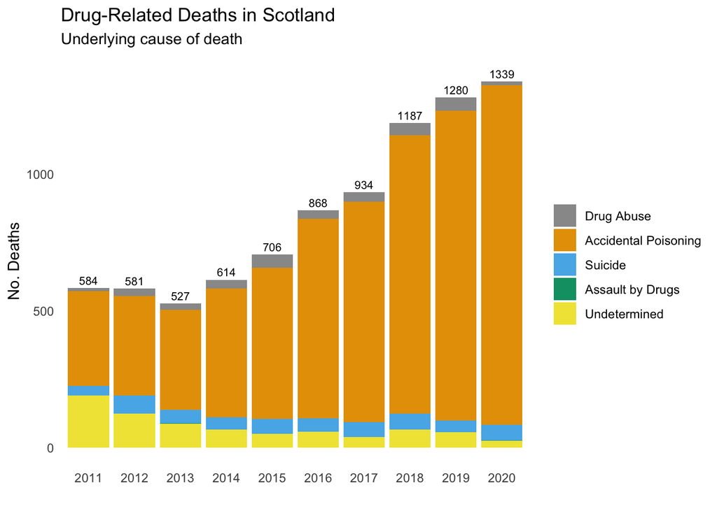

## Table 3

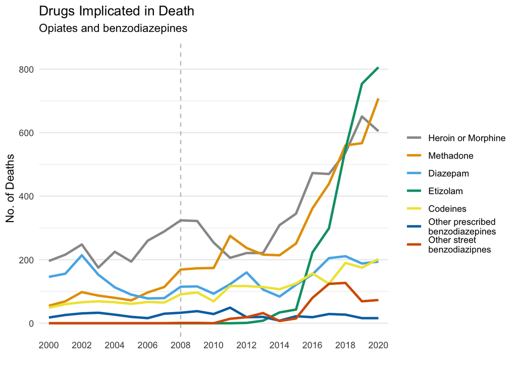

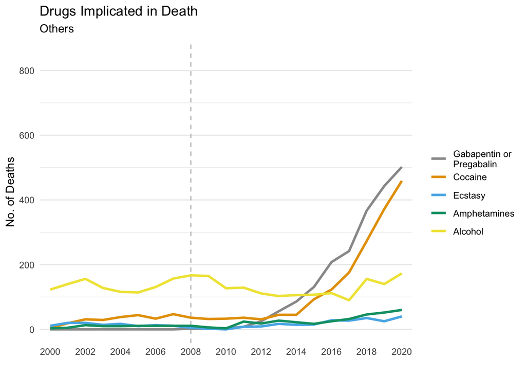

NB: data prior to 2008 uses a different definition than the data from 2008. See notes in table 3.

## Table 4

Table 4 describes quite a lot of data represented in different ways. Each is presented as a different plot.

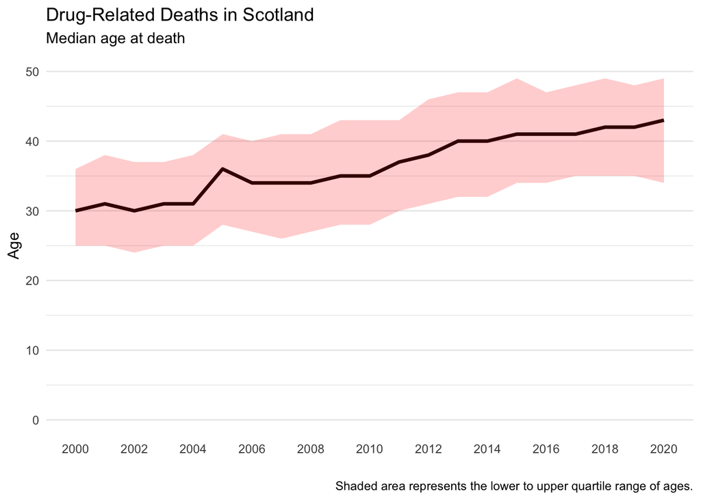

Median age of drug-related death is increasing from 30 in 2000 to 43 in 2020.

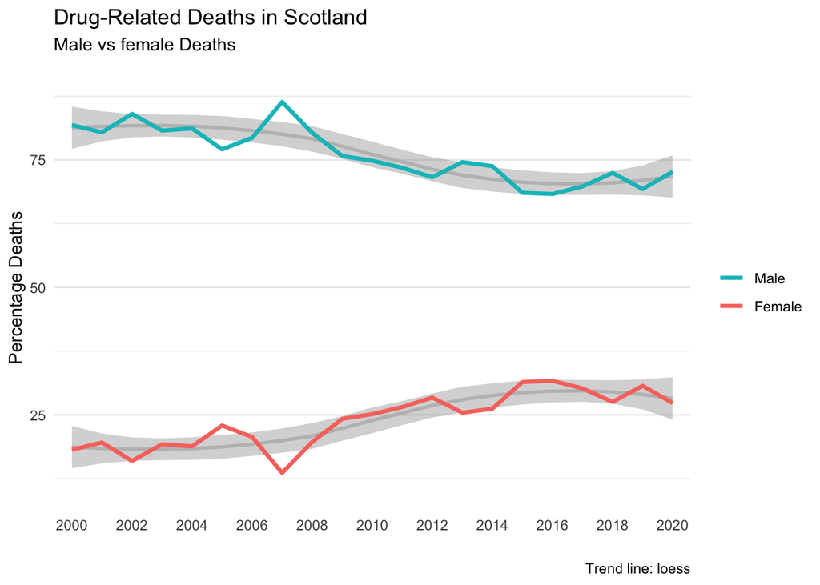

Males are mostly affected by drug-related deaths. Females were increasing, but may have stablised.

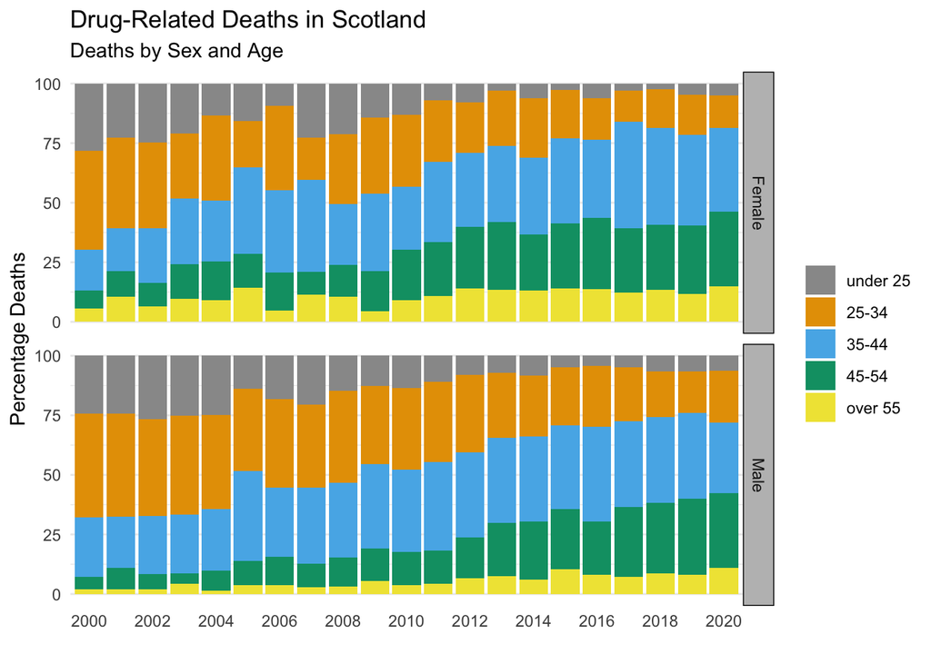

In 2000 deaths were largely in the under 35s. In 2020 they are dominated by the 35 and over.

## Table 5

[figure not shown]

## Table 6

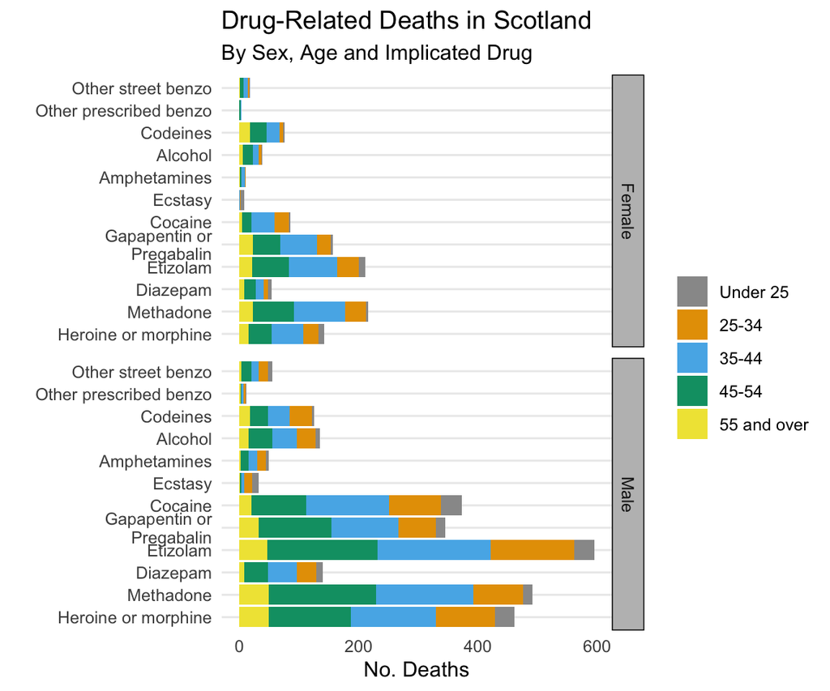

NB: Totals in this chart will be higher than total number of deaths as deaths can have more than one drug implicated.

## Table 8

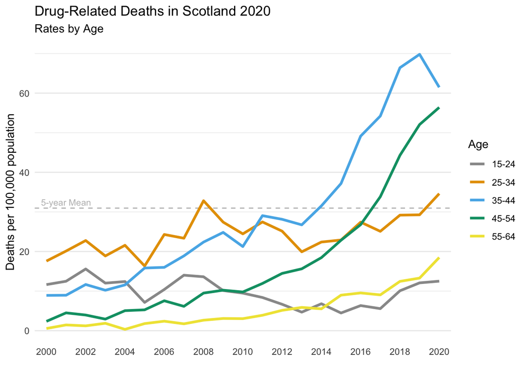

## Regional Changes - Table HB1

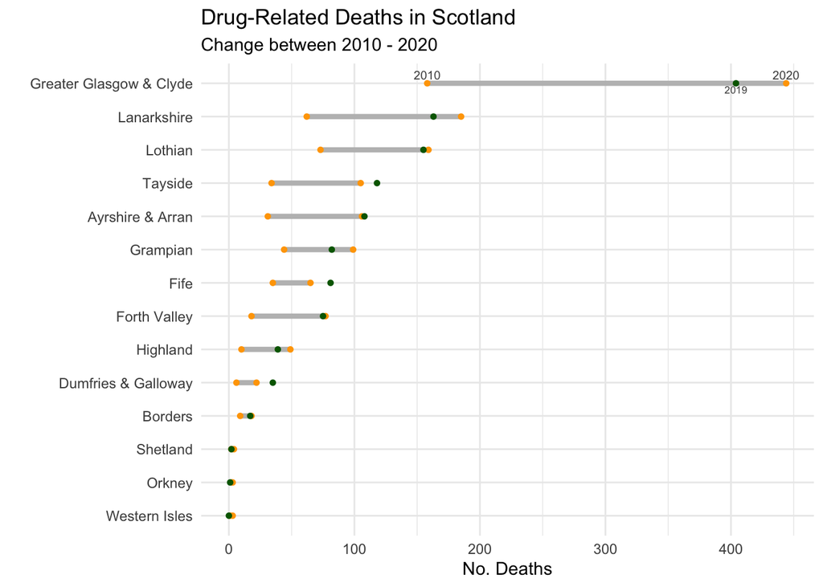

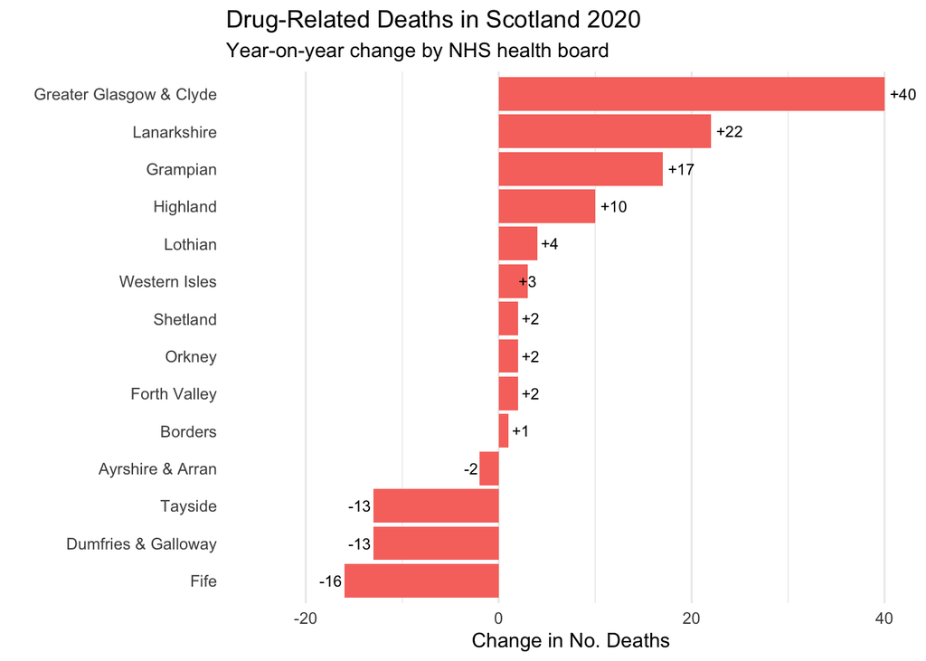

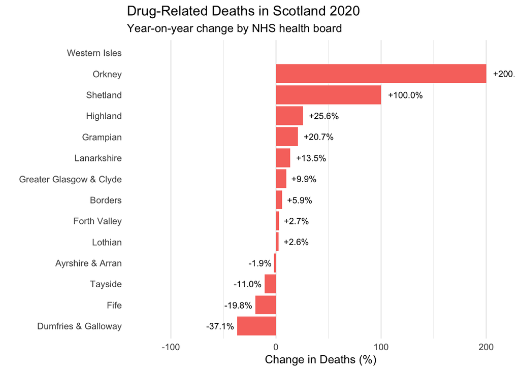

## Council Comparisons

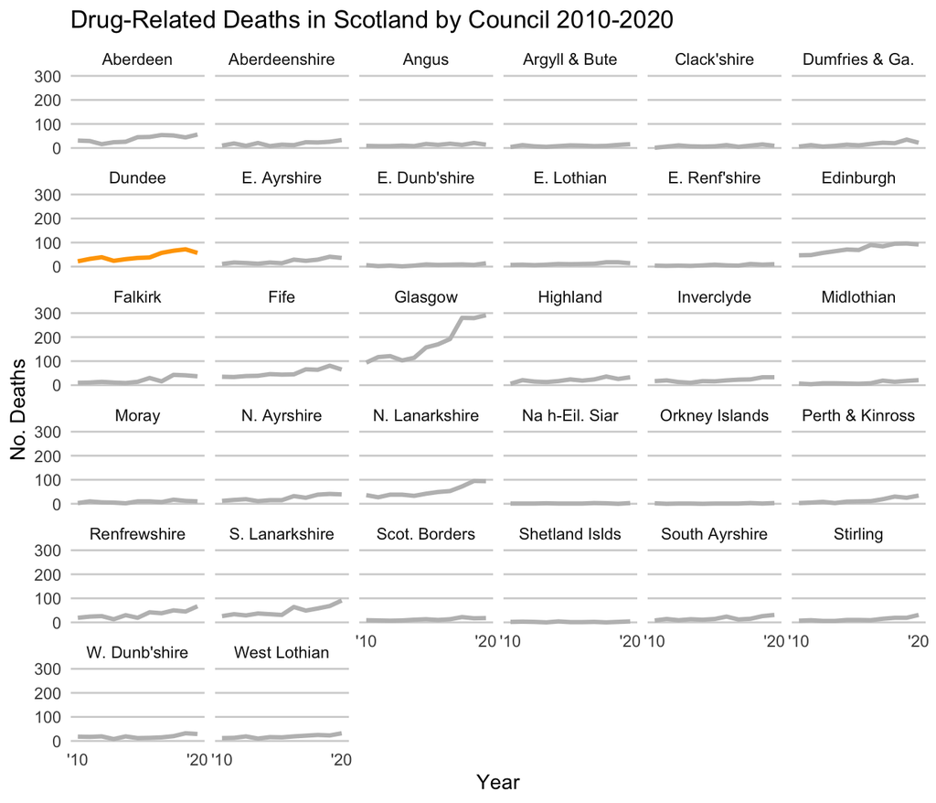

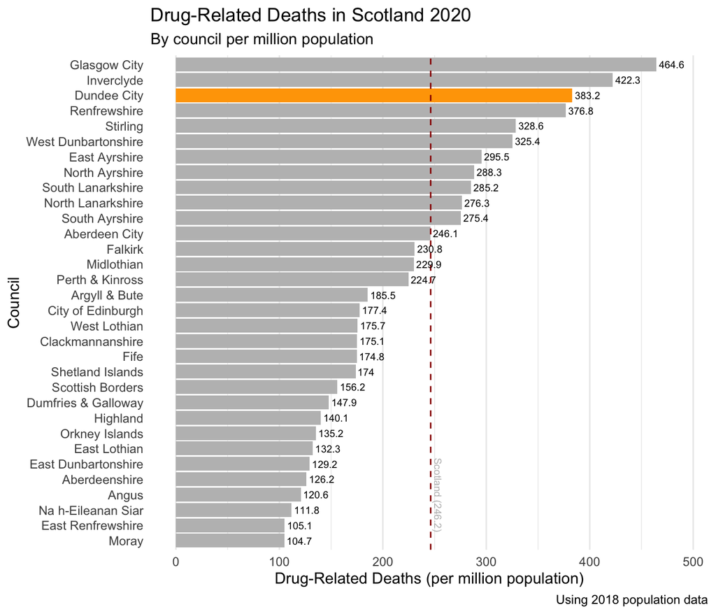

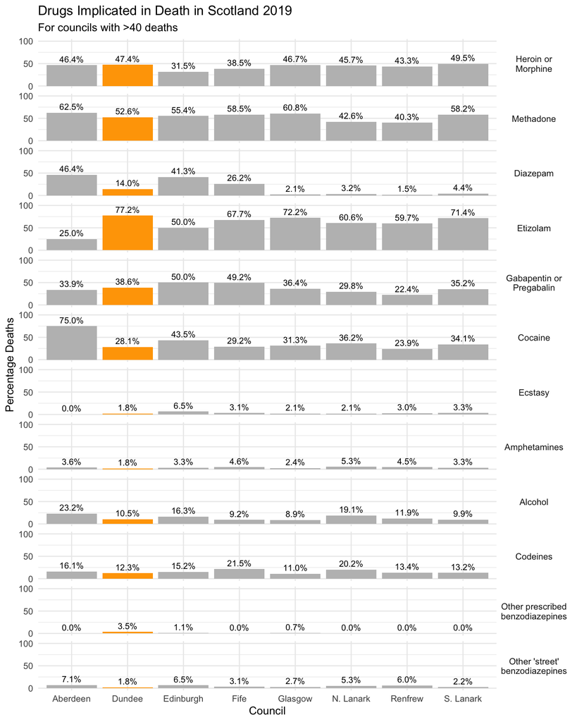

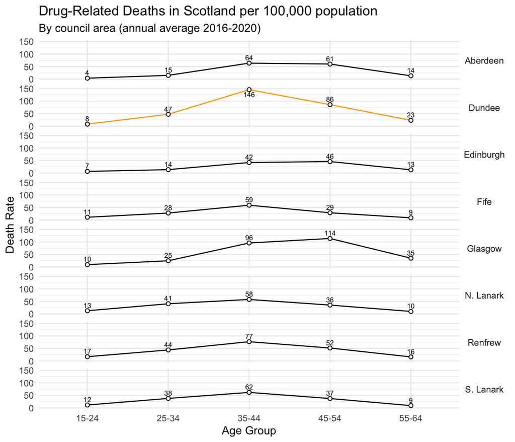

## Different Definitions

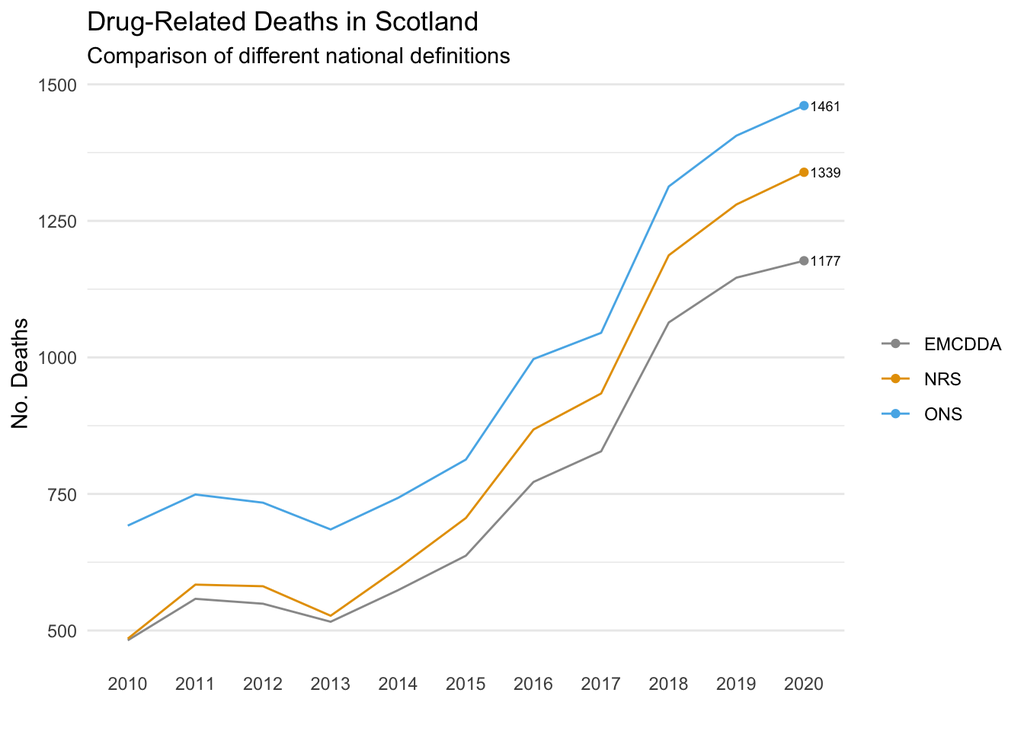

## UK Nations Comparison

*Note:* Not updated since August 2019

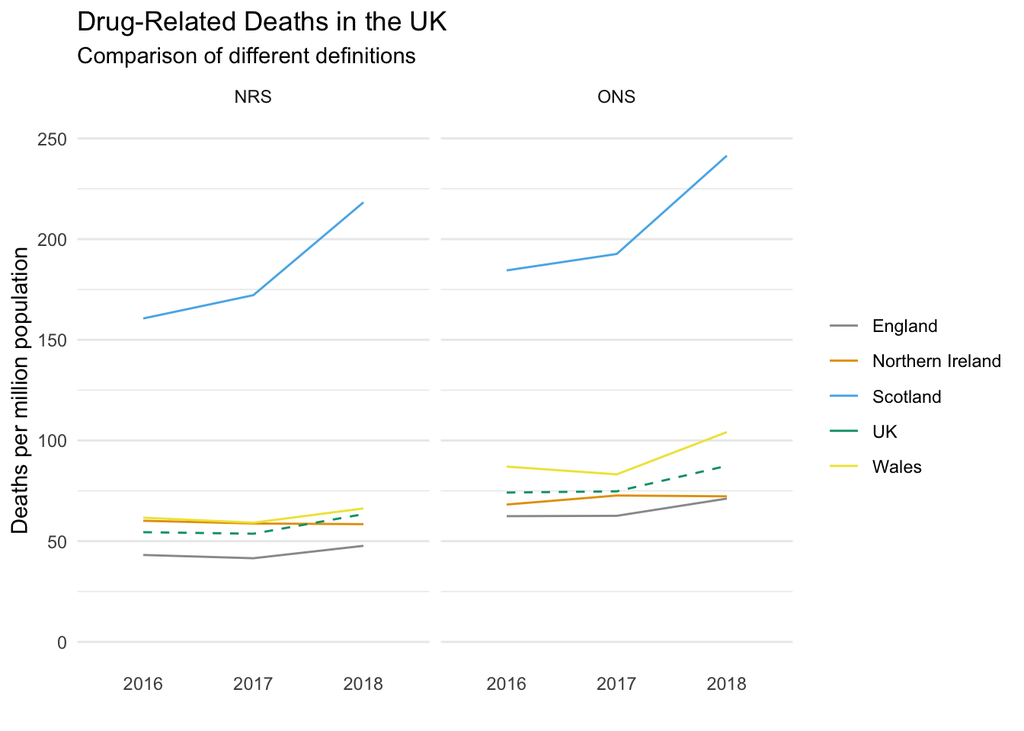

## European Comparison

This data is an attempt to compare the Scotland data with the rest of Europe and the UK. It is an attempt as the UK (i.e. the ONS) and EU (i.e. EMCDDA) define drug-related deaths slightly differently. The NRS have applied the methodology used by the EMCDDA to the Scottish data to get comparable figures.

The current Scottish data is also more up-to-date than the EU’s data so a comparison also is made using data covering the same time periods.

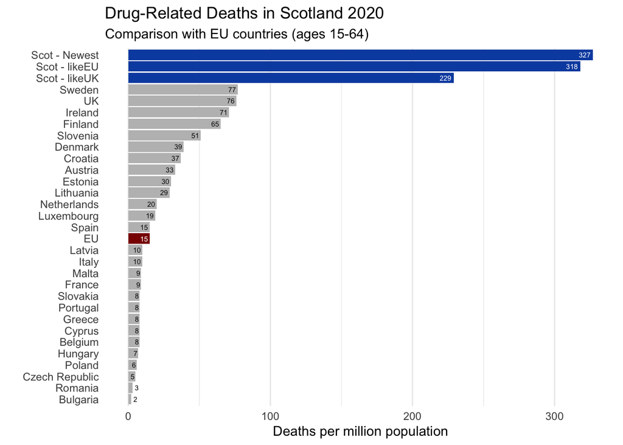